# IODS course project

# Assignment 3: Logistic regression

## Data description

In this assignment we will use logistic regression to analyse Student Performance Data Set, available at: https://archive.ics.uci.edu/ml/datasets/Student+Performance#. The related paper: *P. Cortez and A. Silva. Using Data Mining to Predict Secondary School Student Performance. In A. Brito and J. Teixeira Eds., Proceedings of 5th FUture BUsiness TEChnology Conference (FUBUTEC 2008) pp. 5-12, Porto, Portugal, April, 2008, EUROSIS, ISBN 978-9077381-39-7.* The Student Performance Data Set involves measures of secondary school student performance in mathematics and Portuguese language, with a variety of background variables collected by using school reports and questionnaires.

In a data wrangling script (found in data/create_alc.R in my Git repository) the data for mathematics and Portuguese language were combined. A variable of interest, “high alcohol consumption” was created as a logical variable based on participant reports of alcohol consumption. An average of weekday and weekend consumption (reported on numeric scale from 1 - very low to 5 - very high), and for values higher than 2, high alcohol consumption was coded as true.

First, including some packages for later use, and reading in the data.

```r
# suppress output to keep the course diary page tidy
library(tidyverse) # install.packages("tidyverse")
library(finalfit) # install.packages("finalfit")
library(ggplot2) # install.packages("ggplot2")
library(patchwork) # install.packages("patchwork")
library(boot) # install.packages("boot")

alc <- read_csv("./data/alc.csv")
```

Printing out variable names.

```r
# print out dimensions and column names
dim(alc)
```

```
## [1] 370  35
```

```r
colnames(alc)
```

```
##  [1] "school"     "sex"        "age"        "address"    "famsize"
##  [6] "Pstatus"    "Medu"       "Fedu"       "Mjob"       "Fjob"
## [11] "reason"     "guardian"   "traveltime" "studytime"  "schoolsup"
## [16] "famsup"     "activities" "nursery"    "higher"     "internet"
## [21] "romantic"   "famrel"     "freetime"   "goout"      "Dalc"
## [26] "Walc"       "health"     "failures"   "paid"       "absences"
## [31] "G1"         "G2"         "G3"         "alc_use"    "high_use"
```

The data contains 370 observations for 35 columns which include demographic variables, and variables related to school, studying, and general well-being. Three variables (G1, G2, and G3) contain the course grades for first and second period, and final grade, respectively. In the case of this combined data set, the grade is either the grade for mathematics or portuguese, or their average if both were available. Further variable details can be found in https://archive.ics.uci.edu/ml/datasets/Student+Performance# and will not repeated here.

## Choosing variables for analysis, and initial hypothesis

The analysis will examine high and low alcohol consumption in relation to weekly study time, extra-curricular activities, quality of family relationships, and going out with friends. The choice of variables was not based on exploration of data, but on educated guesses on which variables might be related to alcohol consumption. The initial hypothesis is that higher alcohol consumption correlates with less weekly study time, no extra-curricular activities, poorer quality of family relationships, and going out with friends more.

## Data exploration

To explore the relationships of the four variables with alcohol consumption, each is plotted against the high_use variable in cross-tabulations, bar graphs, and count plots (box plots do not make much sense due to the categorical nature of the variables).

```r
# making a new data frame of selected variables for easier use
alcsel = select(alc, high_use, studytime, activities, famrel, goout)

# create cross-tabulations
ct1 <- with(alcsel, table(high_use, studytime))
ct2 <- with(alcsel, table(high_use, activities))
ct3 <- with(alcsel, table(high_use, famrel))
ct4 <- with(alcsel, table(high_use, goout))

# plot crosstabs
ct1
```

```
##         studytime
## high_use   1   2   3   4
##    FALSE  56 128  52  23
##    TRUE   42  57   8   4
```

```r
ct2
```

```
##         activities
## high_use  no yes
##    FALSE 120 139
##    TRUE   59  52
```

```r
ct3
```

```
##         famrel
## high_use   1   2   3   4   5
##    FALSE   6   9  39 128  77
##    TRUE    2   9  25  52  23
```

```r
ct4
```

```
##         goout
## high_use  1  2  3  4  5
##    FALSE 19 82 97 40 21
##    TRUE   3 15 23 38 32
```

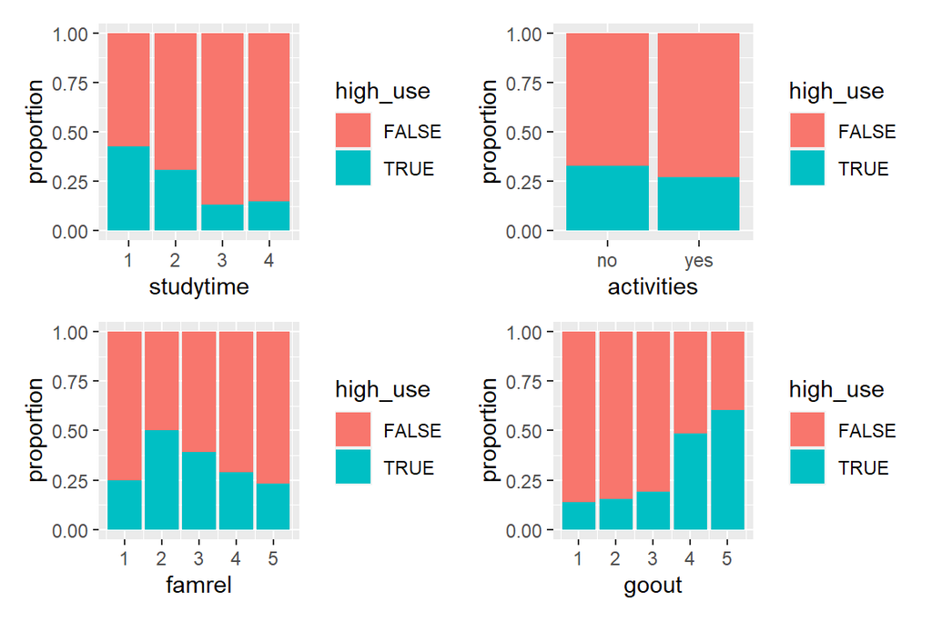

```r
# create bargraphs for proportional counts by high use
bg1 <- ggplot(alcsel, aes(x = studytime, fill = high_use)) + geom_bar(position = "fill") + labs(y = "proportion")
bg2 <- ggplot(alcsel, aes(x = activities, fill = high_use)) + geom_bar(position = "fill") + labs(y = "proportion")
bg3 <- ggplot(alcsel, aes(x = famrel, fill = high_use)) + geom_bar(position = "fill") + labs(y = "proportion")
bg4 <- ggplot(alcsel, aes(x = goout, fill = high_use)) + geom_bar(position = "fill") + labs(y = "proportion")

# plot bargraphs
bg1 + bg2 + bg3 + bg4
```

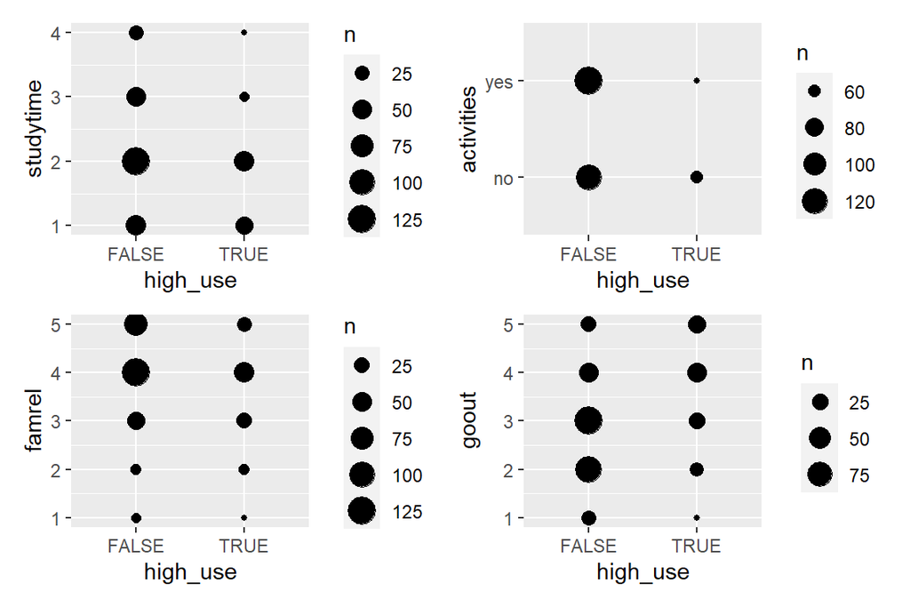

```r
# create boxplots (and count plot for activities) by high use
bp1 <- ggplot(alcsel, aes(x = high_use, y = studytime)) + geom_count()
bp2 <- ggplot(alcsel, aes(x = high_use, y = activities)) + geom_count()
bp3 <- ggplot(alcsel, aes(x = high_use, y = famrel)) + geom_count()
bp4 <- ggplot(alcsel, aes(x = high_use, y = goout)) + geom_count()

# plot boxplots
bp1 + bp2 + bp3 + bp4
```

There is an overall smaller number of students with high alcohol consumption, so considering proportions is more straightforward. From the printout we can see that the initial hypotheses are generally in the right direction: larger proportion of high alcohol consumption students with less weekly study time, no extra-curricular activities, poorer quality of family relationships, and going out with friends more. Especially for weekly study time, and going out with friends, the proportion of high alcohol consumption students clearly varies. For quality of family relationships, the lowest category varies from the general trend, but note that this category contains very few observations. For extra-curricular activities the difference is maybe a little smaller than for the other three variables, but still in the direction of the initial hypothesis.

## Logistic regression

Next, logistic regression is used to explore the relationships. Of the four predictor variables, extra-curricular activities is in a nominal scale, while the other three are in an ordinal scale (one might argue that weekly study time could be considered a ratio scale, but the intervals are not equal). Thus, all predictor variables will be considered as categorical. For this purpose they will be recoded as factors with descriptive labels. Also, due to the fact that there are very few observations (see crosstabulations in previous section), the following categories will be combined: levels 3 and 4 of studytime, levels 1-3 of famrel, levels 1 and 2 of goout.

```r
# factorization of variables, not all are strictly necessary, but I have
# included them for a more uniform printout
alcsel <- alcsel %>%
  mutate(high_use.factor = factor(high_use) %>%
           fct_recode("No" = "FALSE",
                      "Yes" = "TRUE") %>%
           ff_label("High alcohol consumption"),

         studytime = factor(studytime) %>%
           fct_recode("< 2 hours" = "1",
                      "2 to 5 hours" = "2",
                      "> 5 hours" = "3",
                      "> 5 hours" = "4") %>%
           ff_label("Weekly study time"),

         activities = factor(activities) %>%
           fct_recode("No" = "no",
                      "Yes"  = "yes") %>%
           ff_label("Extra-curricular activities"),

         # note: did not find exact wording for labels 2-4
         famrel = factor(famrel) %>%
           fct_recode("Average or below" = "1",
                      "Average or below" = "2",
                      "Average or below" = "3",
                      "Good" = "4",
                      "Very good" = "5") %>%
           ff_label("Quality of family relationships"),

         goout = factor(goout) %>%
           fct_recode("Low or very low" = "1",
                      "Low or very low" = "2",
                      "Average" = "3",
                      "High" = "4",
                      "Very high" = "5") %>%
           ff_label("Going out with friends")
  )

# find logistic linear model
m <- glm(high_use ~ studytime + activities + famrel + goout, data = alcsel, family = "binomial")

# print out a summary
summary(m)
```

```
##
## Call:
## glm(formula = high_use ~ studytime + activities + famrel + goout,
##     family = "binomial", data = alcsel)
##
## Deviance Residuals:
##     Min       1Q   Median       3Q      Max
## -1.8026  -0.7310  -0.4971   0.8534   2.3910
##
## Coefficients:
##                       Estimate Std. Error z value Pr(>|z|)
## (Intercept)            -0.6075     0.3642  -1.668 0.095280 .
## studytime2 to 5 hours  -0.5757     0.2951  -1.951 0.051055 .
## studytime> 5 hours     -1.3350     0.4042  -3.303 0.000957 ***
## activitiesYes          -0.2716     0.2581  -1.052 0.292664
## famrelGood             -0.5852     0.3088  -1.895 0.058098 .
## famrelVery good        -1.0314     0.3656  -2.821 0.004788 **
## gooutAverage            0.4578     0.3584   1.277 0.201520
## gooutHigh               1.8217     0.3647   4.995 5.89e-07 ***
## gooutVery high          2.2845     0.4035   5.662 1.49e-08 ***
## ---
## Signif. codes:  0 '***' 0.001 '**' 0.01 '*' 0.05 '.' 0.1 ' ' 1
##
## (Dispersion parameter for binomial family taken to be 1)
##
##     Null deviance: 452.04  on 369  degrees of freedom
## Residual deviance: 373.44  on 361  degrees of freedom
## AIC: 391.44
##
## Number of Fisher Scoring iterations: 4
```

```r
# compute odds ratios (OR)
OR <- coef(m) %>% exp

# compute confidence intervals (CI)
CI <- confint(m) %>% exp
# print out the odds ratios with their confidence intervals
cbind(OR, CI)
```

```
##                              OR     2.5 %     97.5 %
## (Intercept)           0.5447163 0.2620139  1.0994806
## studytime2 to 5 hours 0.5622833 0.3141813  1.0021797
## studytime> 5 hours    0.2631570 0.1155241  0.5687039
## activitiesYes         0.7621286 0.4580527  1.2629703
## famrelGood            0.5569796 0.3031089  1.0206114
## famrelVery good       0.3565064 0.1716459  0.7229008
## gooutAverage          1.5806238 0.7865068  3.2291985
## gooutHigh             6.1825650 3.0763712 12.9172437
## gooutVery high        9.8210053 4.5403124 22.1956211
```

In the model, the coefficients for a level of a factorial variable are always in comparison to one of the variable levels. For this model, the levels in weekly study time are compared to “< 2 hours”, in extra-curricular activities to “No”, in quality of family relationships to “Average or below”, and in going out with friends to “Low or very low”. In the extra-curricular activities variable, there is no significant difference between levels “Yes” and “No”. In the three other variables, at least one of the levels has a significant difference to the level used as baseline. Residual deviance (with the explanatory variables) is lower that null deviance (with no explanatory variables), but not dramatically so. Nevertheless, the variables seem to provide at least some explanatory power for the model.

Focusing on the odds ratios that do not include 1 in the confidence interval, the model suggests the following odds ratios for high alcohol consumption: 1. Compared to a weekly study time of less than two hours, a student has an odds ratio of ~0.26 if they study more than five hours a week. 2. Compared to quality of family relationships rated average or below, a student has an odds ratio of ~0.36 if they rate their family relationships very good. 3. Compared to a low or very low rating for going out with friends, a student has an odds ratio of ~6.18 with a rating of high, and an odds ratio of ~9.82 with a rating of very high.

## Predictive power

First, the variable for extra-curricular activities will be excluded from the model as it is not statistically significant. Then, a cross-tabulation and a bar graph of predicted and true values for high alcohol consumption will be provided to examine prediction accuracy. Finally, the proportion of inaccurately classified individuals is calculated.

```r
# fit the new model
m <- glm(high_use ~ studytime + famrel + goout, data = alcsel, family = "binomial")

# plot model summary to check
summary(m)
```

```
##
## Call:
## glm(formula = high_use ~ studytime + famrel + goout, family = "binomial",
##     data = alcsel)
##
## Deviance Residuals:
##     Min       1Q   Median       3Q      Max
## -1.8688  -0.6962  -0.5290   0.8038   2.3470
##
## Coefficients:
##                       Estimate Std. Error z value Pr(>|z|)
## (Intercept)            -0.7080     0.3518  -2.013 0.044164 *
## studytime2 to 5 hours  -0.5858     0.2941  -1.992 0.046382 *
## studytime> 5 hours     -1.3782     0.4025  -3.424 0.000618 ***
## famrelGood             -0.5905     0.3085  -1.914 0.055603 .
## famrelVery good        -1.0454     0.3646  -2.867 0.004140 **
## gooutAverage            0.4432     0.3575   1.240 0.214987
## gooutHigh               1.7884     0.3614   4.948 7.48e-07 ***
## gooutVery high          2.2625     0.4017   5.632 1.78e-08 ***
## ---
## Signif. codes:  0 '***' 0.001 '**' 0.01 '*' 0.05 '.' 0.1 ' ' 1
##
## (Dispersion parameter for binomial family taken to be 1)
##
##     Null deviance: 452.04  on 369  degrees of freedom
## Residual deviance: 374.55  on 362  degrees of freedom
## AIC: 390.55
##
## Number of Fisher Scoring iterations: 4
```

```r
# predict() the probability of high_use
probabilities <- predict(m, type = "response")

# add the predicted probabilities to our data frame
alcsel <- mutate(alcsel, probability = probabilities)

# use the probabilities to make a prediction of high_use
alcsel <- mutate(alcsel, prediction = probability > 0.5)

# making a factor version of prediction just for more consistent labeling
alcsel <- alcsel %>%
  mutate(pred.factor = factor(prediction) %>%
           fct_recode("No" = "FALSE",
                      "Yes" = "TRUE") %>%
           ff_label("Prediction of high alcohol consumption")
  )

# tabulate high_use versus predictions
table(high_use = alcsel$high_use.factor, prediction = alcsel$pred.factor)
```

```
##         prediction
## high_use  No Yes
##      No  238  21
##      Yes  65  46
```

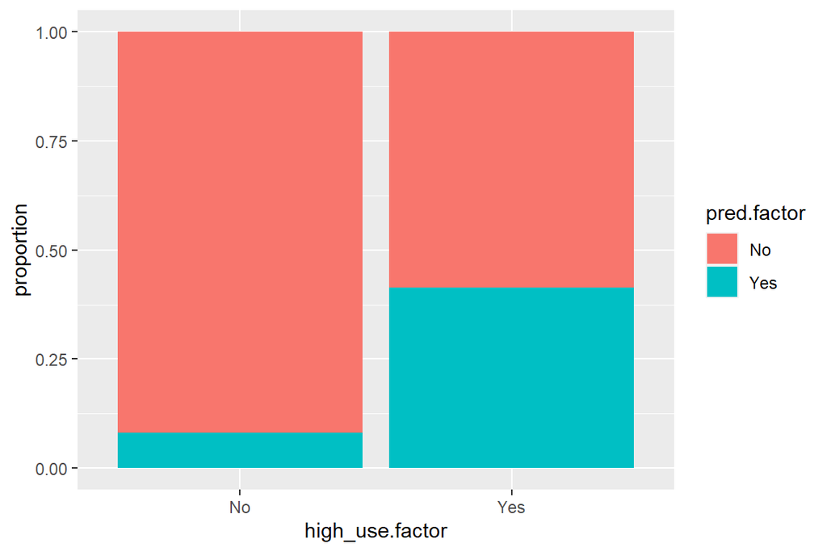

```r
# plot of high_use versus predictions
ggplot(alcsel, aes(x = high_use.factor, fill = pred.factor)) + geom_bar(position = "fill") + labs(y = "proportion")
```

```r
# define a loss function (mean prediction error)
loss_func <- function(class, prob) {
  n_wrong <- abs(class - prob) > 0.5
  mean(n_wrong)
}

# call the loss function to compute the average number of wrong predictions
loss_func(class = alcsel$high_use, prob = alcsel$probability)
```

```
## [1] 0.2324324
```

From the output it can be seen that the model predictions are far from perfect, but clearly better than chance. Proportionally, there are far more errors by predicting “no” for high alcohol consumption, when true value is “yes”. The overall proportion of inaccurately classified individuals is ~0.23.

To compare our model predictions against some simple guessing strategy, we could draw random permutations of the high_use vector and compare how many times our model has better prediction accuracy than the random samples.

```r
# store model inaccuracy in variable
model_inacc <- loss_func(class = alcsel$high_use, prob = alcsel$probability)

# define a new loss function for logical values
loss_func_perm <- function(class, perm) {
  n_wrong <- class != perm
  mean(n_wrong)
}

# create empty vector for prediction inaccuracy
wrong_pred <- c()

# create a loop to draw random samples and calculate inaccuracy
for (ii in 1:10000) {

  set.seed(ii) # for reproducibility
  high_use_perm <- sample(alcsel$high_use)

  # call the loss function to compute the average number of wrong predictions
  wrong_pred[ii] <- loss_func_perm(class = alcsel$high_use, perm = high_use_perm)
}

# calculate proportion of larger inaccuracies from permutations
mean(wrong_pred > model_inacc)
```

```
## [1] 1
```

Even with 10000 different random permutations, there was not a single instance where randomly guessing high alcohol consumption (in the correct ratio) would have been more accurate than the model predictions.

Finally, the code snippet below performs 10-fold cross-validation for the model.

```r
# 10-fold cross-validation
cv <- cv.glm(data = alc, cost = loss_func, glmfit = m, K = 10)

# average number of wrong predictions in the cross validation
cv$delta[1]
```

```
## [1] 0.2486486
```

The prediction error for this model is ~0.25, which is very slightly less than the 0.26 error in the exercise set.

```
## [1] "Last updated Tue Dec 13 16:48:24 2022"
```

# Assignment 4: Clustering and classification

In this assignment we will use clustering and classification to analyze a data set included in the MASS package. First, let’s take a quick look at what the “Housing Values in Suburbs of Boston” data set contains. We will refer to the data simply as Boston from here on out.

```r
# load in packages for future use, suppress output to keep course diary page tidy
# include MASS package for the Boston data set
library(MASS) # install.packages("MASS")
library(tidyr) # install.packages("tidyverse")
library(corrplot) # install.packages("corrplot")
library(ggplot2) # install.packages("ggplot2")
library(GGally) # install.packages("GGally")
```

```r
# load the data
data("Boston")

# explore the dataset
str(Boston)
```

```
## 'data.frame':    506 obs. of  14 variables:
##  $ crim   : num  0.00632 0.02731 0.02729 0.03237 0.06905 ...
##  $ zn     : num  18 0 0 0 0 0 12.5 12.5 12.5 12.5 ...
##  $ indus  : num  2.31 7.07 7.07 2.18 2.18 2.18 7.87 7.87 7.87 7.87 ...
##  $ chas   : int  0 0 0 0 0 0 0 0 0 0 ...
##  $ nox    : num  0.538 0.469 0.469 0.458 0.458 0.458 0.524 0.524 0.524 0.524 ...
##  $ rm     : num  6.58 6.42 7.18 7 7.15 ...
##  $ age    : num  65.2 78.9 61.1 45.8 54.2 58.7 66.6 96.1 100 85.9 ...
##  $ dis    : num  4.09 4.97 4.97 6.06 6.06 ...
##  $ rad    : int  1 2 2 3 3 3 5 5 5 5 ...
##  $ tax    : num  296 242 242 222 222 222 311 311 311 311 ...
##  $ ptratio: num  15.3 17.8 17.8 18.7 18.7 18.7 15.2 15.2 15.2 15.2 ...
##  $ black  : num  397 397 393 395 397 ...
##  $ lstat  : num  4.98 9.14 4.03 2.94 5.33 ...
##  $ medv   : num  24 21.6 34.7 33.4 36.2 28.7 22.9 27.1 16.5 18.9 ...
```

```r
dim(Boston)
```

```
## [1] 506  14
```

We find that the data has 506 observations of 14 variables, 12 of them continuous numerical, and 2 categorical. The column names are not self-explanatory, but more information can be found in: https://stat.ethz.ch/R-manual/R-devel/library/MASS/html/Boston.html. Without giving a full list, we can find that the variables include statistics of zoning, housing, and demographics by town area, and importantly measures of air pollution. In the original paper *Harrison, D. and Rubinfeld, D.L. (1978) Hedonic prices and the demand for clean air. J. Environ. Economics and Management 5, 81–102.* the data are used to estimate willingness to “pay for clean air”.